# Loutre_analyse_Lieu_de_Greve

Pablo

2025-05-27

# 1 Importation des packages

# 2 Importation des données - Secteur : Lieu Greve

## 2.1 Correction des données - Mise en forme - Secteur : Lieu Greve

# 3 Importation avec data 2025

```r
base_greve_raw <-
  readxl::read_xls(path = '../raw_data/Suivi loutre mars_25.xls',
                   skip = 1,
                   col_names = T)
```

## 3.1 Correction des données - Mise en forme - Secteur : Lieu Greve avec data 2025

```r
base_greve <- base_greve_raw %>%
  janitor::clean_names() %>%
  dplyr::select(
    point_n,
    itineraire,
    x,
    y,
    commune,
    cours_deau,
    bilan_choix_du_site,
    epreinte_oct20,
    date_suivi_fev_mars21,
    marquage_suivi_fev_mars21,
    date_suivi_oct21,
    marquage_suivi_oct21,
    observateurs_suivi_oct21,
    date_suivi_mars22,
    marquage_suivi_mars22,
    observateurs_suivi_mars22,
    date_suivi_decembre22,
    marquage_suivi_decembre22,
    observateurs_suivi_decembre22,
    date_suivi_mars23,
    marquage_suivi_mars23,
    observateurs_suivi_mars23,
    date_suivi_octobre_24,
    marquage_suivi_octobre_24,
    observateurs_suivi_octobre_24,
    date_suivi_mars_25,
    marquage_suivi_mars_25,
    observateurs_suivi_mars_25
  ) %>%
  dplyr::rename(
    code_site = point_n,
    y = x,
    x = y,
    marquage_suivi_oct_20 = epreinte_oct20
  ) %>%
  dplyr::mutate(date_suivi_octobre_24 = as.Date(as.numeric(date_suivi_octobre_24), origin = "1899-12-30")) %>%
  dplyr::mutate(date_suivi_oct_20 = as.Date("2020-10-01")) %>%
  dplyr::mutate(across(
    c(
      date_suivi_fev_mars21,
      date_suivi_oct21,
      date_suivi_mars22,
      date_suivi_decembre22,
      date_suivi_mars23,
      date_suivi_oct_20,
      date_suivi_mars_25
    ),
    ~ as.POSIXct(.x)
  )) %>%
  mutate(across(starts_with("marquage_suivi_"), as.character)) %>%
  tidyr::pivot_longer(
    cols = c(
      date_suivi_oct_20,
      marquage_suivi_oct_20,
      date_suivi_fev_mars21,
      marquage_suivi_fev_mars21,
      date_suivi_oct21,
      marquage_suivi_oct21,
      observateurs_suivi_oct21,
      date_suivi_mars22,
      marquage_suivi_mars22,
      observateurs_suivi_mars22,
      date_suivi_decembre22,
      marquage_suivi_decembre22,
      observateurs_suivi_decembre22,
      date_suivi_mars23,
      marquage_suivi_mars23,
      observateurs_suivi_mars23,
      date_suivi_octobre_24,
      marquage_suivi_octobre_24,
      observateurs_suivi_octobre_24,
      date_suivi_mars_25,
      marquage_suivi_mars_25,
      observateurs_suivi_mars_25
    ),
    names_to = c(".value", "session"),
    names_pattern = "(date_suivi|marquage_suivi|observateurs_suivi)_(.*)"
  ) %>%
  rename(
    date_visite = date_suivi,
    statut_presence = marquage_suivi,
    observateurs = observateurs_suivi
  ) %>%
  dplyr::mutate(
    annee = year(date_visite),
    mois = month(date_visite),
    jour = day(date_visite),
    code_site = as.factor(code_site),
    statut_presence = case_when(
      tolower(statut_presence) == "oui" ~ 1,
      suppressWarnings(as.numeric(statut_presence)) >= 1 ~ 1,
      tolower(statut_presence) %in% c("non", "peut_etre") ~ 0,
      TRUE ~ 0
    ),
    statut_observation = ifelse(statut_presence == 1, "Présent", "Absent"),
    statut_presence = as.factor (statut_presence),
    jour = ifelse(jour == 1, NA, jour),
    annee = ifelse(annee == 2002, 2021, annee),
    y = str_replace_all(y, ",", ""),
    x = str_replace_all(x, " ", ""),
    passage = ifelse(mois <= 6, 1, 2),
    date_visite = ifelse(
      date_visite == as.Date("2002-02-24"),
      "2021-02-24",
      as.character(date_visite)
    ),
    observateurs_clean = observateurs %>%
      str_to_lower() %>%
      str_replace_all(" et ", "_") %>%
      str_replace_all("[[:space:]]+", "_") %>%
      str_replace_all("[^a-z0-9_]", "") %>%
      stri_trans_general("latin-ascii")
  ) %>%
  dplyr::mutate(observateurs_clean = as.factor(
    ifelse(
      observateurs_clean == "maxime_chapelle_romain_salaun",
      "maxime_chapelle_romain_salun",
      observateurs_clean
    )
  )) %>%
  dplyr::filter(!is.na(code_site), !is.na(itineraire))
```

A corriger :

- Le code_site 9 et 121 semble mal positionné : liée au manque de précision des coordonnées GPS

Correction :

- X et Y sont inversé
- Supprimer la dernière ligne + ligne 72
- si statut_présence = ‘oui’ ou >= 1 , = 1 sinon = 0
- pb encodage date octobre 2024
- session fev_mars 2021 -> noté 2002 -> corriger
- La modalité “peut-être” tranformé en “0” donc absent

ATTENTION - LA DATE 1 octobre 2020 Est FICTIVE pour pouvoir créer la colonne année et mois

# 4 Représentation cartographique du secteur d’étude et des sites correspondants

[interactive chart not shown]

# 5 Statistiques descriptives - Secteur Lieu de Greve

## 5.1 Sites de prospection - Secteur Lieu de Greve - 1 er passage (Printemps)

[output not shown]

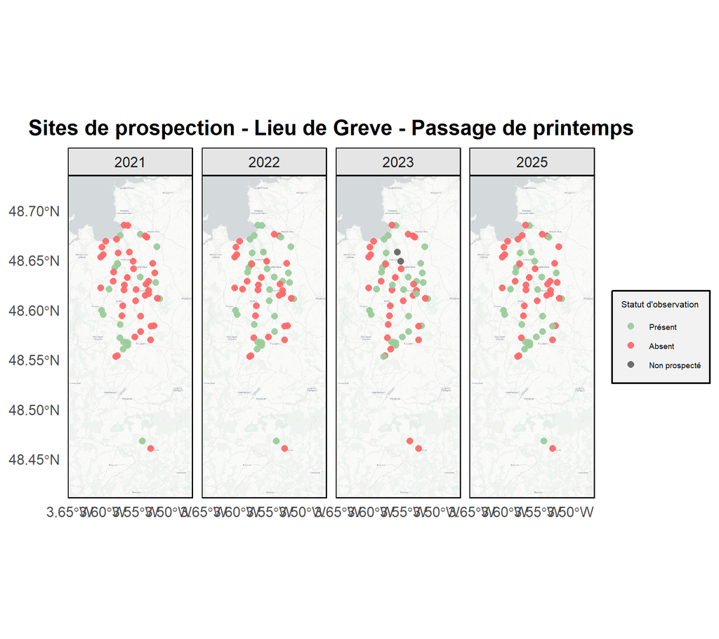

Figure 1: Statut de présence de la loutre sur les sites de prospection en fonction des années - Secteur Lieu de Greve - 1 er passage (Printemps)

## 5.2 Sites de prospection - Secteur Lieu de Greve - 2 e passage (hivernal)

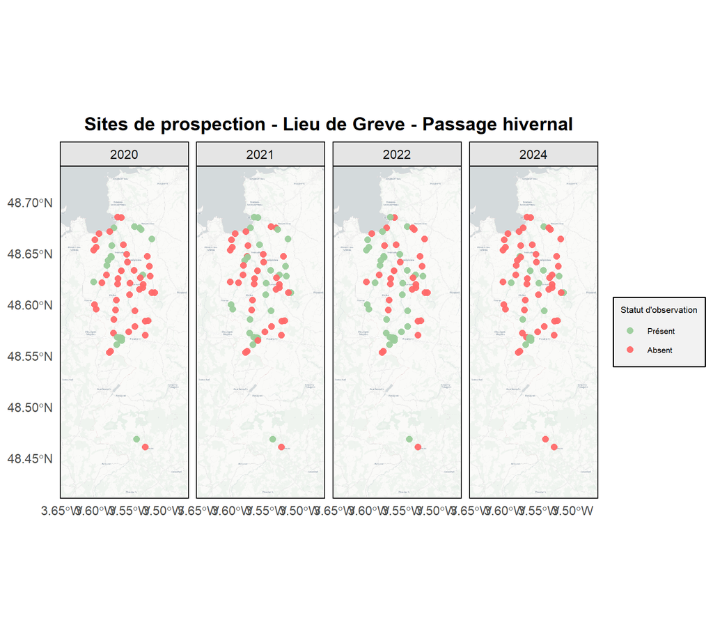

Figure 2: Statut de présence de la loutre sur les sites de prospection en fonction des années - Secteur Lieu de Greve - 2 e passage (Hivernal)

## 5.3 Statut d’observation des sites prospectée en fonction des années, 1er passage (printemps)

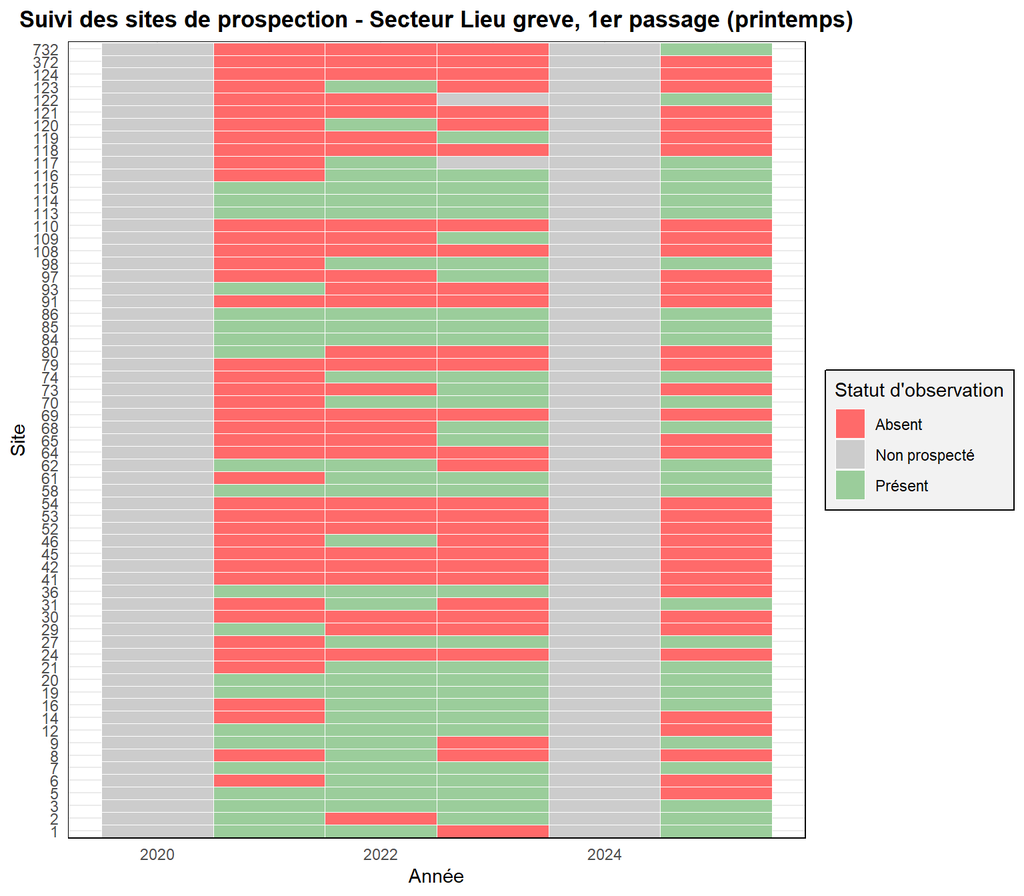

Figure 3: Statut d’observation des sites prospectée en fonction des années, 1er passage (printemps)

## 5.4 Statut d’observation des sites prospectée en fonction des années, 2e passage (hiver)

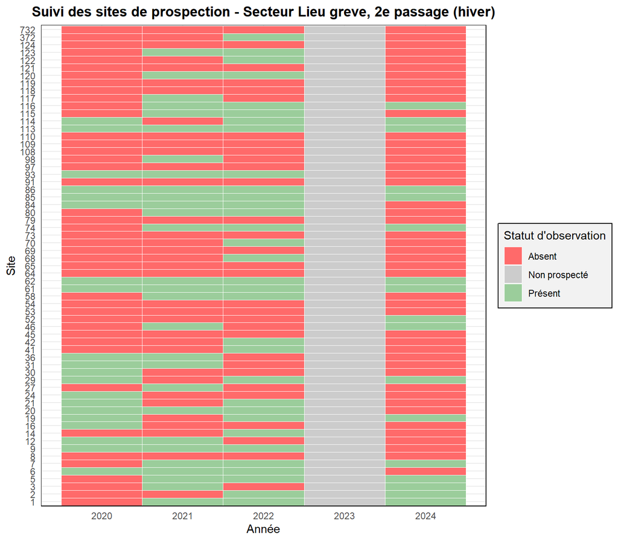

Figure 4: Statut d’observation des sites prospectée en fonction des années, 2e passage (hiver)

## 5.5 Pourcentages de présence de la loutre en fonction des années, 1e passage (printemps)

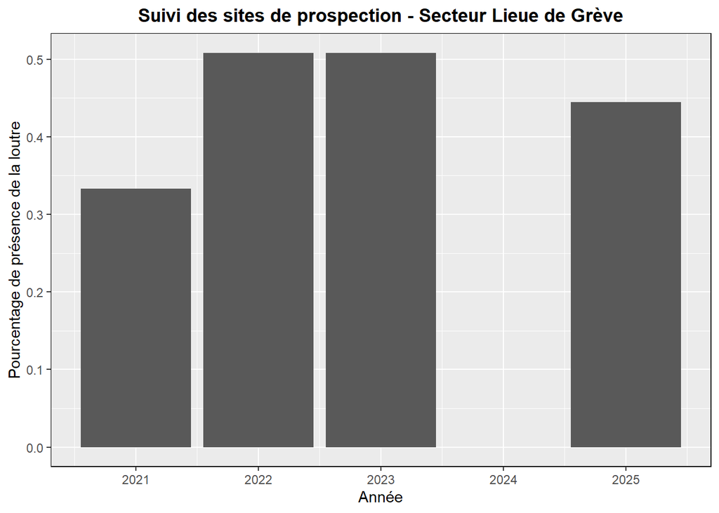

Figure 5: Pourcentages de présence de la loutre en fonction des années

## 5.6 Pourcentages de présence de la loutre en fonction des années, 2e passage (hiver)

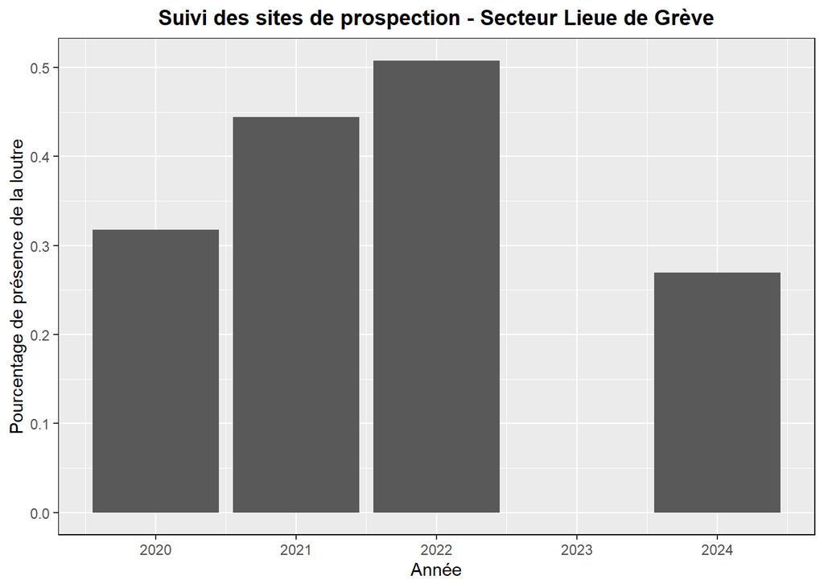

Figure 6: Pourcentages de présence de la loutre en fonction des années

## 5.7 Nombre d’observations de présence et absence de la loutre en fonction des années, 1 er passage (primtemps)

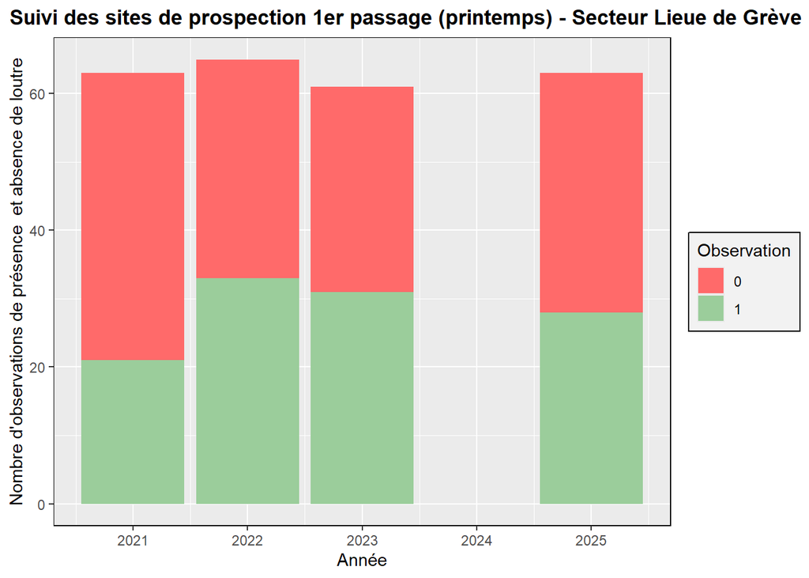

Figure 7: Nombre d’observations de présence et absence de la loutre en fonction des années

## 5.8 Nombre d’observations de présence et absence de la loutre en fonction des années, 2e passage (hivernale)

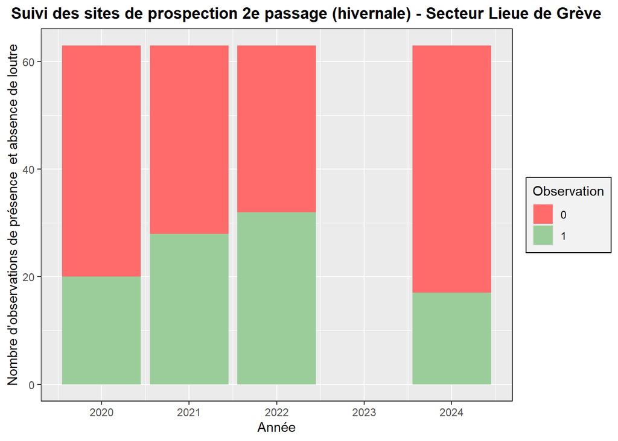

Figure 8: Nombre d’observations de présence et absence de la loutre en fonction des années

# 6 Modèle 1 : Le statut d’observation depend de l’année pour le passage printemps

```r
greve_year_factor_spring <- base_greve %>%
  mutate(annee = as.factor(annee))%>%
  filter(passage == 1,
         annee == 2021:2025)
```

On decide ici de prendre en compte le suivi uniquement de 2021 à 2025 sans considérere le suivi de 2020 non réalisé. Remarque : le suivi de l’année 2024, n’a pas été réalisé.

## 6.1 Construction du modèle

### 6.1.1 **Definition des types de variables**

- **Variable réponse** : Statut_présence, variable qualitative binaire, nominale
- **Variable explicative** :
- Annee, variable qualitative ordinale
- Site, variable qualitative ordinale

### 6.1.2 **Choix de la distribution de référence**

=> **Distribution Binomiale**

### 6.1.3 **Choix de la fonction de lien**

=> **logit**

### 6.1.4 **Modèle mixte**

```r
mod1.0<- glmer(statut_presence~annee+(1|code_site), family=binomial(link = "logit"), data = greve_year_factor_spring)
```

## 6.2 Vérification de l’ajustement du modèle aux données

**Vérification de l’indépendance des résidus**

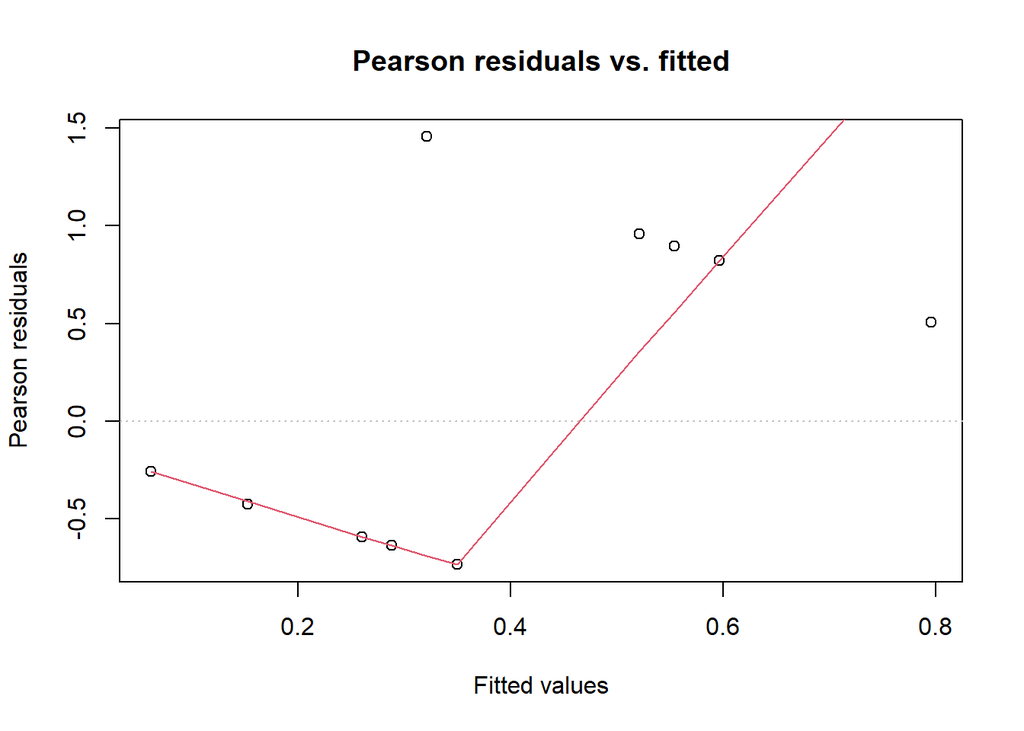

```r
plotresid(mod1.0)
```

### 6.2.1 **Remplacer la fonction de lien “logit” par “probit”**

```r
mod1.1<- glmer(statut_presence~annee+(1|code_site), family=binomial(link = "probit"), data = greve_year_factor_spring)
```

## 6.3 Vérification de l’ajustement du modèle aux données

**Vérification de l’indépendance des résidus**

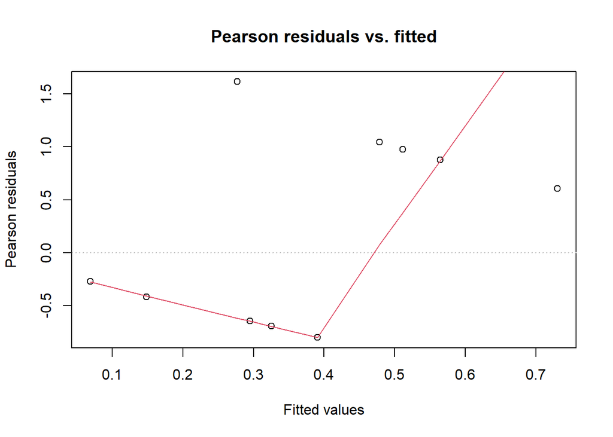

```r
plotresid(mod1.1)
```

### **Remplacer la fonction de lien “logit” par “cauchit”**

```r
mod1.2<- glmer(statut_presence~annee+(1|code_site), family=binomial(link = "cauchit"), data = greve_year_factor_spring)
```

## 6.4 Vérification de l’ajustement du modèle aux données

**Vérification de l’indépendance des résidus**

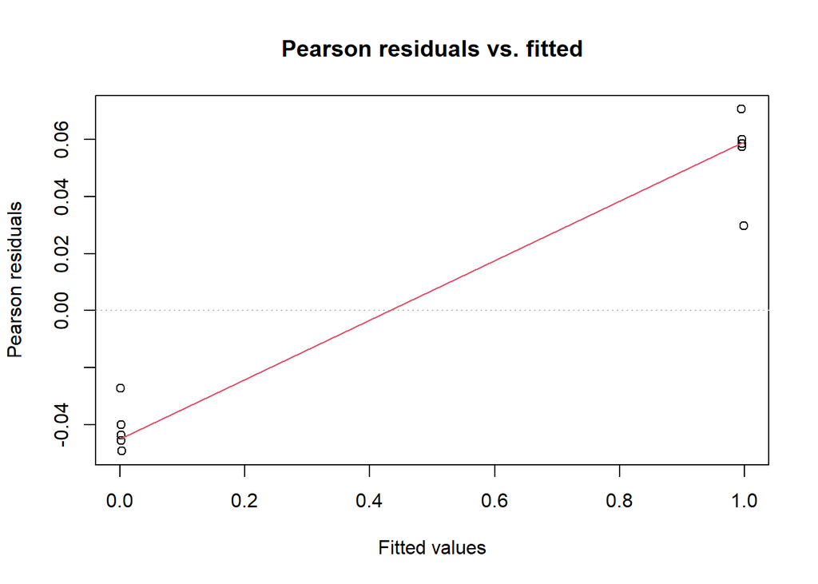

```r
plotresid(mod1.2)
```

### **Remplacer la fonction de lien “logit” par “cloglog”**

```r
mod1.3<- glmer(statut_presence~annee+(1|code_site), family=binomial(link = "cloglog"), data = greve_year_factor_spring)
```

## 6.5 Vérification de l’ajustement du modèle aux données

**Vérification de l’indépendance des résidus**

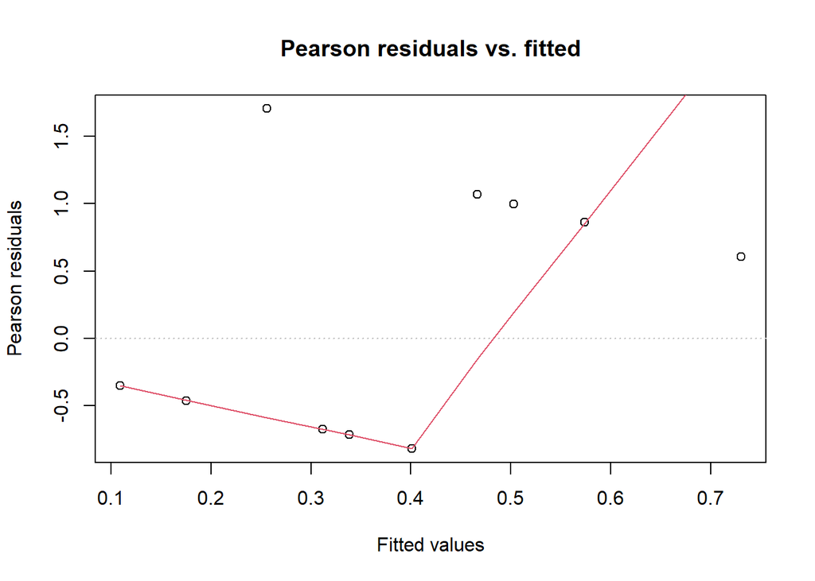

```r
plotresid(mod1.3)
```

**Valeur des coefficients (estimate)**

```r
summary(mod1.1)
```

```
## Generalized linear mixed model fit by maximum likelihood (Laplace
##   Approximation) [glmerMod]
##  Family: binomial  ( probit )
## Formula: statut_presence ~ annee + (1 | code_site)
##    Data: greve_year_factor_spring
##
##      AIC      BIC   logLik deviance df.resid
##     70.3     79.8    -30.2     60.3       44
##
## Scaled residuals:
##     Min      1Q  Median      3Q     Max
## -0.8009 -0.6944 -0.4173  0.8789  1.6154
##
## Random effects:
##  Groups    Name        Variance Std.Dev.
##  code_site (Intercept) 0.366    0.605
## Number of obs: 49, groups:  code_site, 37
##
## Fixed effects:
##             Estimate Std. Error z value Pr(>|z|)
## (Intercept)  -0.2577     0.4478  -0.575    0.565
## annee2022    -0.1016     0.6154  -0.165    0.869
## annee2023     0.2632     0.6302   0.418    0.676
## annee2025    -0.9419     0.7313  -1.288    0.198
##
## Correlation of Fixed Effects:
##           (Intr) an2022 an2023
## annee2022 -0.700
## annee2023 -0.714  0.496
## annee2025 -0.538  0.450  0.439
```

## 6.6 Capacité explicative globale

```r
r.squaredGLMM(mod1.0)
```

```
##                    R2m       R2c
## theoretical 0.11402799 0.3953624
## delta       0.09615641 0.3333974
```

```r
r.squaredGLMM(mod1.1)
```

```
##                   R2m       R2c
## theoretical 0.1298528 0.3629798
## delta       0.0920352 0.2572676
```

## 6.7 Exploitation du modèle

### 6.7.1 **Test de Wald**

```r
Anova(mod1.1)
```

```
## Analysis of Deviance Table (Type II Wald chisquare tests)
##
## Response: statut_presence
##        Chisq Df Pr(>Chisq)
## annee 2.8611  3     0.4135
```

```r
#IC_mod1.1 <- confint(mod1.1, oldNames = FALSE, method = "boot")
```

# 7 Modèle 2 : Le statut d’observation depend de l’année pour le passage hiver

```r
greve_year_factor_winter <- base_greve %>%
  mutate(annee = as.factor(annee))%>%
  filter(passage == 2,
         annee == 2020:2024)
```

On prends en compte le suivi uniquement de 2020 à 2024 sans considérere le suivi de 2025 pas encore réalisé.

## 7.1 Construction du modèle

### 7.1.1 **Definition des types de variables**

- **Variable réponse** : Statut_présence, variable qualitative binaire, nominale
- **Variable explicative** :
- Annee, variable qualitative ordinale
- Site, variable qualitative ordinale

### 7.1.2 **Choix de la distribution de référence**

=> **Distribution Binomiale**

### 7.1.3 **Choix de la fonction de lien**

=> **logit**

### 7.1.4 **Modèle mixte**

```r
mod2.0<- glmer(statut_presence~annee+(1|code_site), family=binomial(link = "logit"), data = greve_year_factor_winter)
```

## 7.2 Vérification de l’ajustement du modèle aux données

**Vérification de l’indépendance des résidus**

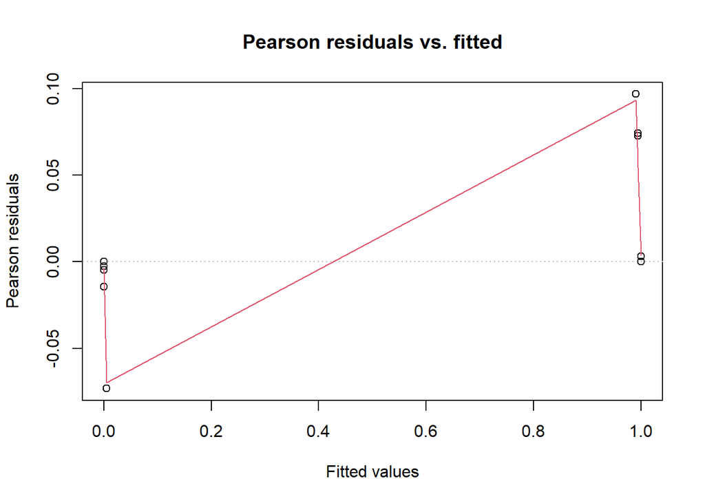

```r
plotresid(mod2.0)
```

### 7.2.1 **Remplacer la fonction de lien “logit” par “probit”**

```r
mod2.1<- glmer(statut_presence~annee+(1|code_site), family=binomial(link = "probit"), data = greve_year_factor_winter)
```

## 7.3 Vérification de l’ajustement du modèle aux données

**Vérification de l’indépendance des résidus**

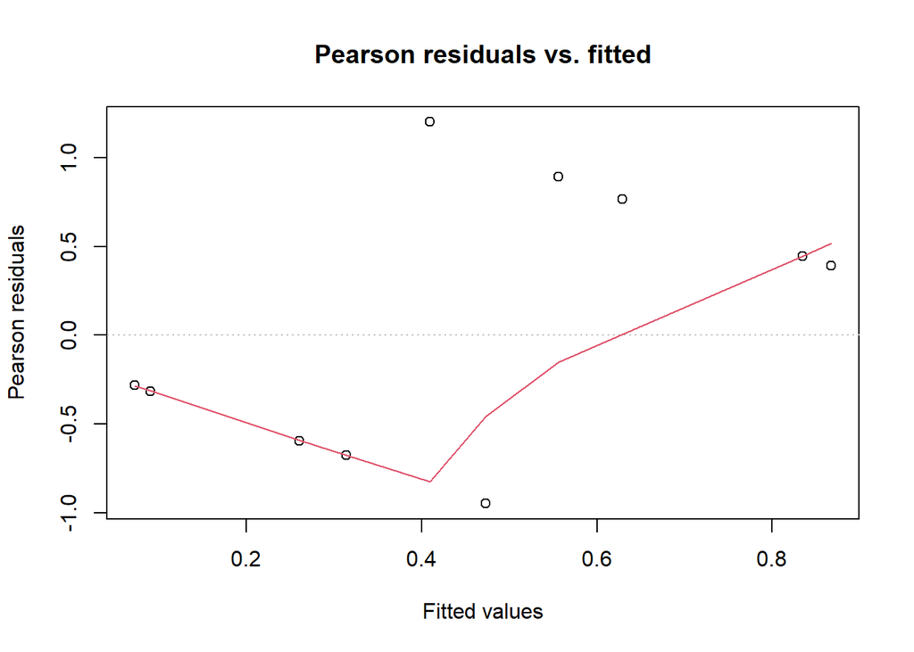

```r
plotresid(mod2.1)
```

**Valeur des coefficients (estimate)**

```r
summary(mod2.1)
```

```
## Generalized linear mixed model fit by maximum likelihood (Laplace
##   Approximation) [glmerMod]
##  Family: binomial  ( probit )
## Formula: statut_presence ~ annee + (1 | code_site)
##    Data: greve_year_factor_winter
##
##      AIC      BIC   logLik deviance df.resid
##     71.2     80.9    -30.6     61.2       46
##
## Scaled residuals:
##     Min      1Q  Median      3Q     Max
## -0.9479 -0.4541 -0.2798  0.4457  1.2009
##
## Random effects:
##  Groups    Name        Variance Std.Dev.
##  code_site (Intercept) 0.9848   0.9924
## Number of obs: 51, groups:  code_site, 38
##
## Fixed effects:
##             Estimate Std. Error z value Pr(>|z|)
## (Intercept)  -1.1635     0.8555  -1.360    0.174
## annee2021     1.8407     1.2762   1.442    0.149
## annee2022     1.3335     1.0667   1.250    0.211
## annee2024     0.3623     0.8389   0.432    0.666
##
## Correlation of Fixed Effects:
##           (Intr) an2021 an2022
## annee2021 -0.877
## annee2022 -0.868  0.772
## annee2024 -0.698  0.557  0.674
```

## 7.4 Capacité explicative globale

```r
r.squaredGLMM(mod2.0)
```

```
##                    R2m       R2c
## theoretical 0.04980177 0.9990004
## delta       0.04978981 0.9987604
```

```r
r.squaredGLMM(mod2.1)
```

```
##                   R2m       R2c
## theoretical 0.2156849 0.6048314
## delta       0.1747283 0.4899794
```

## 7.5 Exploitation du modèle

### 7.5.1 **Test de Wald**

```r
Anova(mod2.1)
```

```
## Analysis of Deviance Table (Type II Wald chisquare tests)
##
## Response: statut_presence
##       Chisq Df Pr(>Chisq)
## annee 2.506  3     0.4742
```

# 8 Modèle 3 : Le statut d’observation depend de l’année (passage printemps) et de l’observateurs

```r
greve_year_factor_obs <- base_greve%>%
  mutate(annee = as.factor(annee),
         passage = as.factor(passage))%>%
  dplyr::filter(passage == 1)
```

## 8.1 Construction du modèle

### 8.1.1 **Definition des types de variables**

- **Variable réponse** : Statut_présence, variable qualitative binaire, nominale
- **Variable explicative** :
- Annee, variable qualitative ordinale
- Site, variable qualitative ordinale
- Observateurs, variable qualitative nominale

### 8.1.2 **Choix de la distribution de référence**

=> **Distribution Binomiale**

### 8.1.3 **Choix de la fonction de lien**

=> **logit**

### 8.1.4 **Modèle mixte**

```r
mod3.0<- glmer(statut_presence~annee + observateurs_clean + (1|code_site), family=binomial(link = "logit"), data = greve_year_factor_obs)
```

## 8.2 Vérification de l’ajustement du modèle aux données

**Vérification de l’indépendance des résidus**

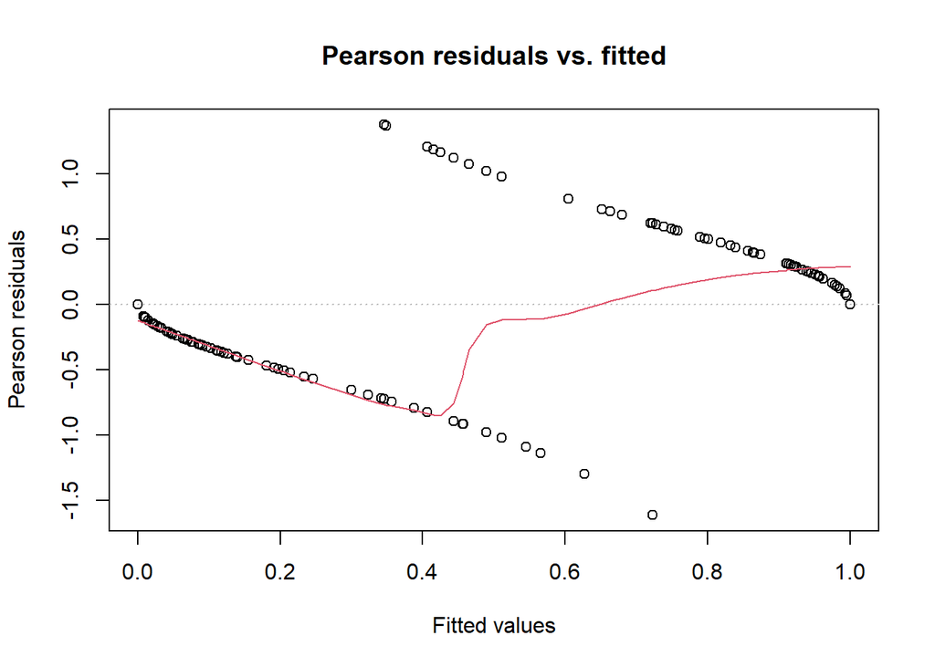

```r
plotresid(mod3.0)
```

```r
mod3.1<- glmer(statut_presence~annee + observateurs_clean + (1|code_site), family=binomial(link = "probit"), data = greve_year_factor_obs)
```

## 8.3 Vérification de l’ajustement du modèle aux données

**Vérification de l’indépendance des résidus**

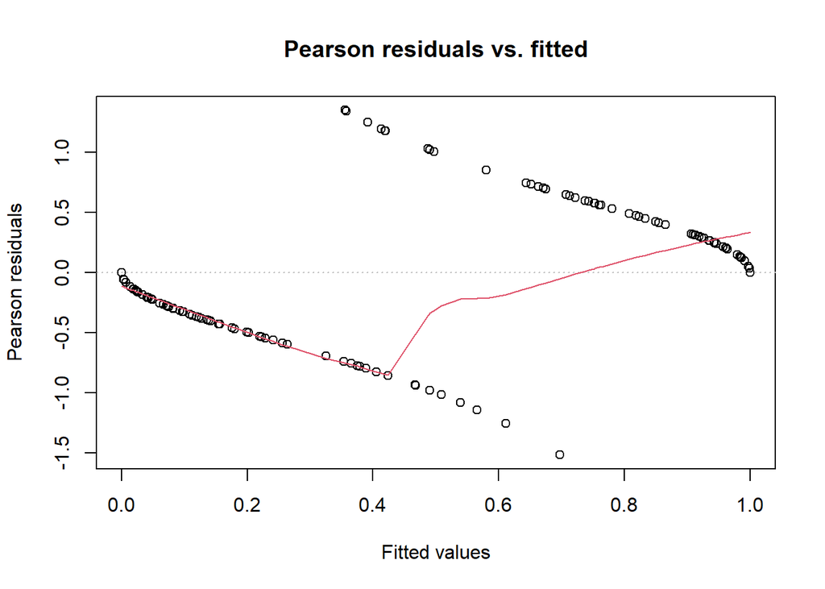

```r
plotresid(mod3.1)
```

**Valeur des coefficients (estimate)**

```r
summary(mod3.1)
```

```
## Generalized linear mixed model fit by maximum likelihood (Laplace
##   Approximation) [glmerMod]
##  Family: binomial  ( probit )
## Formula: statut_presence ~ annee + observateurs_clean + (1 | code_site)
##    Data: greve_year_factor_obs
##
##      AIC      BIC   logLik deviance df.resid
##    252.8    337.1   -100.4    200.8      163
##
## Scaled residuals:
##     Min      1Q  Median      3Q     Max
## -1.5166 -0.3567  0.0000  0.3157  1.3473
##
## Random effects:
##  Groups    Name        Variance Std.Dev.
##  code_site (Intercept) 2.647    1.627
## Number of obs: 189, groups:  code_site, 63
##
## Fixed effects:
##                                                                      Estimate
## (Intercept)                                                        -7.989e+00
## annee2023                                                           1.024e+00
## annee2025                                                           1.001e+00
## observateurs_cleanamandine_gyomlai_erminia_zambon                   7.024e+00
## observateurs_cleanamandine_gyomlai_marion_ruvoen                    7.308e+00
## observateurs_cleandavid_menanteau                                   8.425e+00
## observateurs_cleandavid_menanteau_elouan_berquer                    8.774e+00
## observateurs_cleandavid_menanteau_elouan_brequer                    1.246e+01
## observateurs_cleandavid_menanteau_marion_ruvoen                     7.262e+00
## observateurs_cleandavid_menanteauelouan_berquer                     6.307e+00
## observateurs_cleanelouan_berquer                                   -4.763e-01
## observateurs_cleanelouan_berquer_pablo                              7.627e+00
## observateurs_cleanelouan_berquerpablo                               1.210e+01
## observateurs_cleangunol_chauviere_amandine_gyomlai_david_menanteau  1.124e+01
## observateurs_cleangunol_chauviere_romain_salaun_erminia_zambon      6.566e+00
## observateurs_cleanhouz_alexandrejules_karpinskilouka_lahemar        6.763e+00
## observateurs_cleanmalle_coussens                                    6.362e+00
## observateurs_cleanmalle_coussens_elouan_berquer                     7.518e+00
## observateurs_cleanmalle_coussens_elouan_berquer_pablo               6.897e-01
## observateurs_cleanmalle_coussens_elouan_brequer                     5.711e+00
```

[output cut: 68 more lines]

```
## observateurs_cleanelouan_berquer                                      1.000
## observateurs_cleanelouan_berquer_pablo                                0.999
## observateurs_cleanelouan_berquerpablo                                 1.000
## observateurs_cleangunol_chauviere_amandine_gyomlai_david_menanteau    0.997
## observateurs_cleangunol_chauviere_romain_salaun_erminia_zambon        0.998
## observateurs_cleanhouz_alexandrejules_karpinskilouka_lahemar          0.999
## observateurs_cleanmalle_coussens                                      0.999
## observateurs_cleanmalle_coussens_elouan_berquer                       0.999
## observateurs_cleanmalle_coussens_elouan_berquer_pablo                 1.000
## observateurs_cleanmalle_coussens_elouan_brequer                       0.999
## observateurs_cleanmarine_ihuel_amlie_desmas                           0.998
## observateurs_cleanmarine_ihuel_loane_rouiller                         0.998
## observateurs_cleanmaxime_chapelle_amandine_gyomlai                    0.998
## observateurs_cleanmaxime_chapelle_amlie_desmas                        0.998
## observateurs_cleanmaxime_chapelle_romain_salun                        0.998
```

```
## fit warnings:
## fixed-effect model matrix is rank deficient so dropping 1 column / coefficient
## optimizer (Nelder_Mead) convergence code: 0 (OK)
## unable to evaluate scaled gradient
## Model failed to converge: degenerate  Hessian with 3 negative eigenvalues
```

# 9 Modèle 4 : Le statut d’observation depend de l’année (passage hivernal) et de l’observateurs

```r
greve_year_factor_obs <- base_greve%>%
  mutate(annee = as.factor(annee),
         passage = as.factor(passage))%>%
  dplyr::filter(passage == 2)
```

## 9.1 Construction du modèle

### 9.1.1 **Definition des types de variables**

- **Variable réponse** : Statut_présence, variable qualitative binaire, nominale
- **Variable explicative** :
- Annee, variable qualitative ordinale
- Site, variable qualitative ordinale
- Observateurs, variable qualitative nominale

### 9.1.2 **Choix de la distribution de référence**

=> **Distribution Binomiale**

### 9.1.3 **Choix de la fonction de lien**

=> **logit**

### 9.1.4 **Modèle mixte**

```r
mod4.0<- glmer(statut_presence~annee + observateurs_clean + (1|code_site), family=binomial(link = "logit"), data = greve_year_factor_obs)
```

## 9.2 Vérification de l’ajustement du modèle aux données

**Vérification de l’indépendance des résidus**

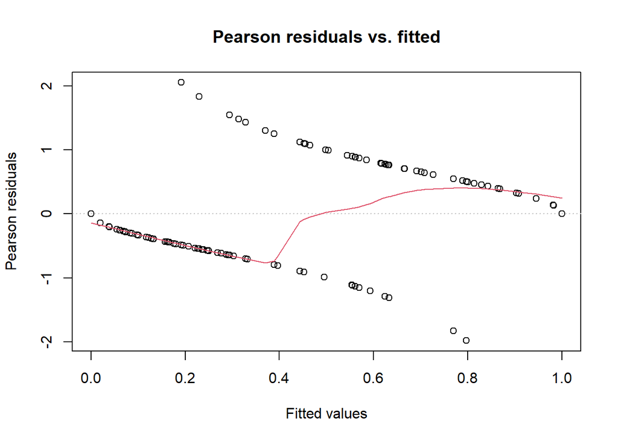

```r
plotresid(mod4.0)
```

```r
mod4.1<- glmer(statut_presence~annee + observateurs_clean + (1|code_site), family=binomial(link = "probit"), data = greve_year_factor_obs)
```

## 9.3 Vérification de l’ajustement du modèle aux données

**Vérification de l’indépendance des résidus**

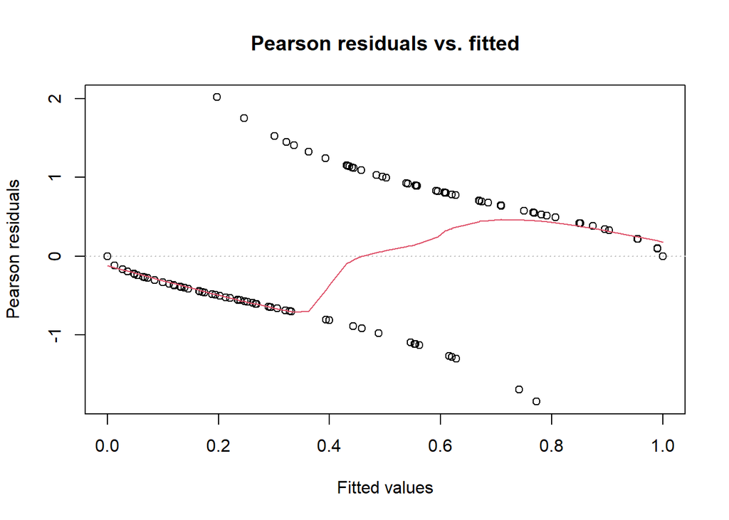

```r
plotresid(mod4.1)
```

# 10 Modèle 5 : Le statut d’observation depend de l’année et du passage

```r
greve_year_factor_season <- base_greve%>%
  mutate(annee = as.factor(annee),
         passage = as.factor(passage),
         observateurs_clean = as.factor(observateurs_clean))
```

## 10.1 Construction du modèle

### 10.1.1 **Definition des types de variables**

- **Variable réponse** : Statut_présence, variable qualitative binaire, nominale
- **Variable explicative** :
- Annee, variable qualitative ordinale
- Site, variable qualitative ordinale
- Observateurs, variable qualitative nominale

### 10.1.2 **Choix de la distribution de référence**

=> **Distribution Binomiale**

### 10.1.3 **Choix de la fonction de lien**

=> **logit**

### 10.1.4 **Modèle mixte**

```r
mod5.0<- glmer(statut_presence~annee + observateurs_clean + passage + (1|code_site), family=binomial(link = "logit"), data = greve_year_factor_season)
```

## 10.2 Vérification de l’ajustement du modèle aux données

**Vérification de l’indépendance des résidus**

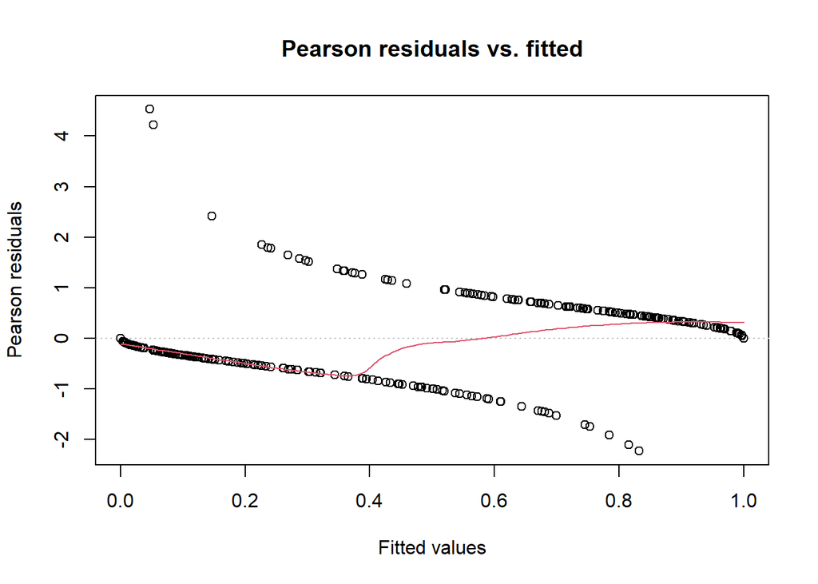

```r
plotresid(mod5.0)
```

```r
mod5.1<- glmer(statut_presence~annee + observateurs_clean + passage + (1|code_site), family=binomial(link = "probit"), data = greve_year_factor_season)
```

## 10.3 Vérification de l’ajustement du modèle aux données

**Vérification de l’indépendance des résidus**

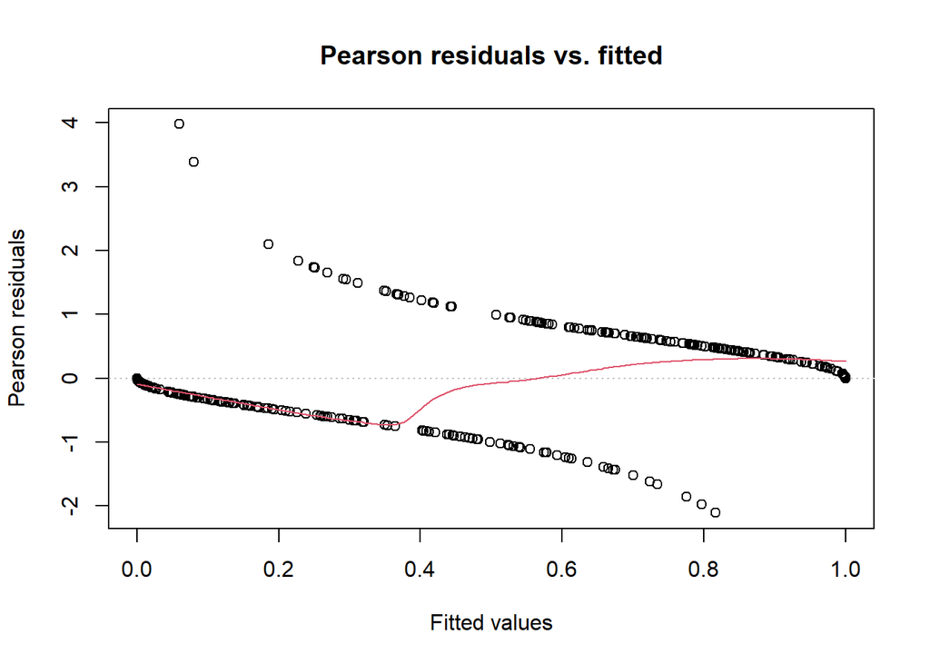

```r
plotresid(mod5.1)
```